# Combining R & Python in RStudio

Michael Stadler

May 27, 2020

# 1 Introduction

In this exercise, we will work with RStudio as an editor and use its support for code from different laguages.

## 1.1 Useful links

- “R Markdown: The Definitive Guide” (free online book): https://bookdown.org/yihui/rmarkdown/
- `knitr` chunk options: https://yihui.org/knitr/options/
- `reticulate` documenation (R interface to python): https://rstudio.github.io/reticulate/
- `reticulate` and sparse matrices: https://rstudio.github.io/reticulate/articles/calling_python.html#sparse-matrices-1
- `reticulate` webinar: https://resources.rstudio.com/webinars/r-python-in-rstudio-1-2-with-reticulate
- PyCon.DE 2018: “Reticulate: R Interface To Python” (presentation by Jens Bruno Wittek): https://www.youtube.com/watch?v=EJxQSa9lwfM
- Tutorial for using Python in RStudio: https://docs.rstudio.com/tutorials/user/using-python-with-rstudio-and-reticulate/
- `SciPy` documenation: https://docs.scipy.org/doc/scipy/reference/
- `pandas.DataFrame` documentation: https://pandas.pydata.org/pandas-docs/stable/reference/api/pandas.DataFrame.html
- `matplotlib` documentation: https://matplotlib.org/contents.html
- `ggplot2` documentation: https://ggplot2.tidyverse.org/

# 2 RStudio IDE

## 2.1 RStudio notebook support

Similar to Jupyter, RStudio now also supports a notebook interface (see [link](https://bookdown.org/yihui/rmarkdown/notebook.html) for details). Code chunks can be run independently and the output is captured and visualized already in the editor interface. However, as pointed out during the introduction, this creates the risk of running things out of order and creating an inconsistent state.

I will demonstrate this issue using the two code cunks below:

```r
x <- 2
```

```r
x + 1
```

```
## [1] 3
```

While working on an `Rmarkdown` document, the ability to see immediately the output of a newly written chunk is very convenient, and I also make use of it. A safe way to create consistent output though is to always compile the whole document when its finished and only share the resulting output.

## 2.2 Defining code chunks

The content of an `Rmarkdown` document (`.Rmd` file extension) is mostly `markdown` (plain text with human-friendly formatting cues, see this [article](https://en.wikipedia.org/wiki/Markdown) on Wikipedia). `Markdown` documents are pure text, but can be compiled into various output formats (HTML, PDF and Word in RStudio).

In addition, `Rmarkdown` documents can contain code chunks that will be run upon compilation, and their output (text or figures) can be captured and integrated into the generated output file.

For code chunks, multiple languages are supported by RStudio (see [link](https://bookdown.org/yihui/rmarkdown/language-engines.html) for a list). Code chunks are delineated by three backticks (```), and the language is defined in the header:

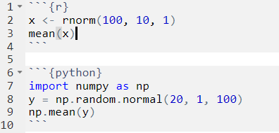

In addition to the language, additional options that apply to that chunk can be defined in the header, such as:

- `fig.width` and `fig.height` control the dimensions of generated figures
- `warnings=FALSE` suppresses warnings
- `echo=FALSE` hides the code in the output
- `eval=FALSE` does not run a code chunk
- `cache=TRUE` caches the output of a chunk (warning: beware of inconsistent state)

You can find more details on chunk options supported by `knitr`, RStudio’s default engine, [here](https://yihui.org/knitr/options/).

As mentioned in the introduction, I use different background colors to indicate code chunks for different languages. These will only become visible in the rendered output document and are defined in a CSS file.

```r
# R code
R.version.string
```

[output not shown]

```python
# python code
import sys
sys.version
```

[output not shown]

```bash
# shell script (bash)
echo ${BASH_VERSION}
```

[output not shown]

# 3 Working with `reticulate`

[figure not shown]

Combining R and Python is made possible using the [reticulate](https://rstudio.github.io/reticulate/) package. It has been created by developers at RStudio (JJ Allaire and Kevin Ushey) and is compatible with Python >= 2.7 and numpy >= 1.6.

It can be installed from [CRAN](https://cran.r-project.org/) using the code below (this is not needed on your virtual machine - it is already installed):

```r
install.packages("reticulate")
```

## 3.1 Selecting which Python to use

The Python instance to be used by [reticulate](https://rstudio.github.io/reticulate/) should be selected at the beginning of an analysis, before the Python process is started.

You can use `py_available()` to check if Python is available on the system and has already been initialized, and `py_discover_config()` if you want to select one from several potential Python instances that provides specific required modules:

```r
# load reticulate package
library(reticulate)

# check if Python is available and has already been initialized
py_available()
```

```
## [1] FALSE
```

```r
# dicsover Python that provides "numpy"
py_discover_config(required_module = "numpy")
```

```
## python:         /usr/bin/python3.6
## libpython:      /usr/lib64/libpython3.6m.so
## pythonhome:     //usr://usr
## version:        3.6.8 (default, Aug  7 2019, 17:28:10)  [GCC 4.8.5 20150623 (Red Hat 4.8.5-39)]
## numpy:          /tungstenfs/groups/gbioinfo/stadler/documents/teaching/SIB_advanced-scRNAseq-course_2020/adv_scrnaseq_2020/combining_python_and_R/pythonlib/numpy
## numpy_version:  1.18.4
## numpy:          /tungstenfs/groups/gbioinfo/stadler/documents/teaching/SIB_advanced-scRNAseq-course_2020/adv_scrnaseq_2020/combining_python_and_R/pythonlib/numpy
##
## NOTE: Python version was forced by RETICULATE_PYTHON
```

By default, [reticulate](https://rstudio.github.io/reticulate/) uses the version of Python found on your PATH (i.e. `Sys.which("python")`). The `use_python()` function, or the `RETICULATE_PYTHON` environment variable enable you to specify an alternate version.

You can also use Python from a virtual or Conda environment using the `use_virtualenv()` and `use_condaenv()` functions. See this [link](https://rstudio.github.io/reticulate/articles/versions.html) for more details.

Finally, environments can also be created, and Python packages can be installed or removed, from within R using the following functions:

- *Conda environments*: `conda_create()`, `conda_install()`, `conda_remove()`
- *Virtual environments*: `virtualenv_create()`, `virtualenv_install()`, `virtualenv_remove()`
- *active environment* (or if unset, the `r-reticulate` environment): `py_install()`

For this course, the virtual machine has `RETICULATE_PYTHON` set, and all required python packages are already installed, so that you don’t have to do anything. On my local server, which I use to write this documenation, I however have to select a particular Python, which I do by setting `RETICULATE_PYTHON` and library path (`PYTHONPATH`).

Finally, we can use `py_config()` to see which Python `reticulate` is using. If you run `py_config()` and Python bindings have not been initialized yet, they will be initialized by that function:

```r
# set python env (only needed on server xenon6)
if (Sys.info()["nodename"] == "xenon6.fmi.ch") { getwd()
    Sys.setenv(PYTHONPATH = file.path(getwd(), "pythonlib"))
    Sys.setenv(RETICULATE_PYTHON = "/usr/bin/python3.6")
} else {
    Sys.setenv(RETICULATE_PYTHON = "/opt/conda/bin/python3")
}

# print config (will initialize Python bindings)
py_config()
```

```
## python:         /usr/bin/python3.6
## libpython:      /usr/lib64/libpython3.6m.so
## pythonhome:     //usr://usr
## version:        3.6.8 (default, Aug  7 2019, 17:28:10)  [GCC 4.8.5 20150623 (Red Hat 4.8.5-39)]
## numpy:          /tungstenfs/groups/gbioinfo/stadler/documents/teaching/SIB_advanced-scRNAseq-course_2020/adv_scrnaseq_2020/combining_python_and_R/pythonlib/numpy
## numpy_version:  1.18.4
##
## NOTE: Python version was forced by RETICULATE_PYTHON
```

```r
# check if Python is available now
py_available()
```

```
## [1] TRUE
```

## 3.2 The `reticulate` Python engine

The integration of R and Python in RStudio is more sophisticated than that of other languages that can be run in code chunks. The Python engine from [reticulate](https://rstudio.github.io/reticulate/) allows you to:

1. run Python chunks (single Python session embedded within your R session, shared variables/state between Python chunks)
2. print Python output (including graphical output from [matplotlib](https://matplotlib.org/)
3. access Python objects from R (using the `py` object)
4. access R objects from Python (using the `r` object)

# 4 Exercises

## 4.1 Ways of executing Python code

There are five ways how you can run Python code from R:

1. `py_run_string()` and `py_eval()` run code provided as a string
2. `py_run_file()` runs code contained in a script file
3. `source_python()` runs code contained in a script file and imports objects into R
4. Python code chunks (only in Rmarkdown documents)
5. interactively using `repl_python()` (read-eval-print-loop)

All five evaluate the Python code in the `__main__` Python module. In contrast to (1) and (2), (3) will in addition make all public (non-module) objects within the main Python module available within the specified R environment. (4) is my personal favorate, because it allows me to write native Python code without `reticulate` specific functions. It is however only available in an Rmarkdown document. (5) is useful to quickly try out something without needing to recompile the Rmarkdown document.

Let’s try this out:

```r
# run code in a string
py_run_string("a = [1, 2, 3]")
py_eval("len(a)")
```

```
## [1] 3
```

```r
exists("a")
```

```
## [1] FALSE
```

```r
# run code in a file
pytempfile <- tempfile()
writeLines("b = [4, 5, 6]", pytempfile)
py_run_file(pytempfile)
py_eval("len(b)")
```

```
## [1] 3
```

```r
exists("b")
```

```
## [1] FALSE
```

```r
# run code in a file and import objects into R
source_python(pytempfile)
exists("b")
```

```
## [1] TRUE
```

```r
b
```

```
## [1] 4 5 6
```

This illustrates that objects are not automatically shared between R and Python processes. Still, they can be easily accessed from the other process (see next section).

- How would you calculate the mean of `a` and export the result into the R environment (find two alternative methods)?

Finally, here is how you could use `repl_python()`:

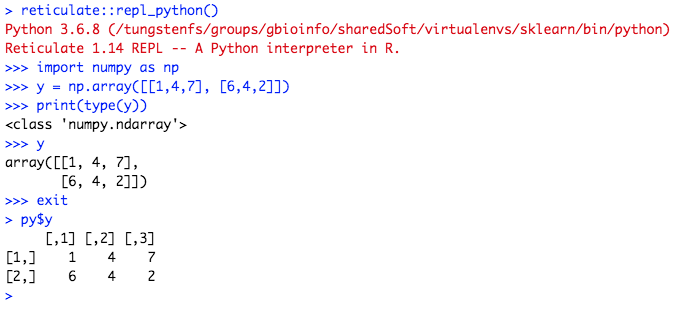

## 4.2 Sharing objects between `R` and `python`

As mentioned in the introduction, [reticulate](https://rstudio.github.io/reticulate/) automatically translates between common objects when switching the language, as summarized in the following table:

| R | Python | Examples |
| --- | --- | --- |
| Single-element vector | Scalar | 1, 1L, TRUE, “foo” |
| Multi-element vector | List | c(1.0, 2.0, 3.0), c(1L, 2L, 3L) |
| List of multiple types | Tuple | list(1L, TRUE, “foo”) |
| Named list | Dict | list(a = 1L, b = 2.0), dict(x = x_data) |
| Matrix/Array | NumPy ndarray | matrix(c(1,2,3,4), nrow = 2, ncol = 2) |
| Data Frame | Pandas DataFrame | data.frame(x = c(1,2,3), y = c(“a”, “b”, “c”)) |
| Function | Python function | function(x) x + 1 |
| Raw | Python bytearray | as.raw(c(1:10)) |
| NULL, TRUE, FALSE | None, True, False | NULL, TRUE, FALSE |

Let’s use the `r` and `py` objects to illustrate sharing of objects.

- Let’s first create numerical values drawn from normal distributions, one in R called `x` and one in Python called `y`:

```r
x <- rnorm(100, 10, 1)
```

```python
import numpy as np
y = np.random.normal(20, 1, 100)
```

- Let’s calculate the mean of `x` and `y`, both in R and in Python:

```r
mean(x)
```

```
## [1] 10.16092
```

```r
mean(py$y)
```

```
## [1] 20.08597
```

```python
np.mean(r.x)
```

```
## 10.160918174857198
```

```python
np.mean(y)
```

```
## 20.08597060865475
```

- Let’s create a python function that calculates and returns the mean of its argument, and call it from R:

```python
def pymean(z):
    return np.mean(z)
```

```r
py$pymean(x)
```

```
## [1] 10.16092
```

```r
py$pymean(py$y)
```

```
## [1] 20.08597
```

## 4.3 Working with tabular data

A particularly nice capability is the built-in support for `pandas` DataFrame objects.

- Make the R built-in data.frame `iris` available in Python as `pyiris` and print its column names (remark: if `pandas` is not available in Python, an R `data.frame` will be converted into a python `dict`)

```r
class(iris)
```

```
## [1] "data.frame"
```

```python
type(r.iris)
```

```
## <class 'pandas.core.frame.DataFrame'>
```

```python
pyiris = r.iris
pyiris.columns
```

```
## Index(['Sepal.Length', 'Sepal.Width', 'Petal.Length', 'Petal.Width',
##        'Species'],
##       dtype='object')
```

- Calculate a concise summary of the dataframe both in R and Python:

```r
summary(iris)
```

```
##   Sepal.Length    Sepal.Width     Petal.Length    Petal.Width          Species
##  Min.   :4.300   Min.   :2.000   Min.   :1.000   Min.   :0.100   setosa    :50
##  1st Qu.:5.100   1st Qu.:2.800   1st Qu.:1.600   1st Qu.:0.300   versicolor:50
##  Median :5.800   Median :3.000   Median :4.350   Median :1.300   virginica :50
##  Mean   :5.843   Mean   :3.057   Mean   :3.758   Mean   :1.199
##  3rd Qu.:6.400   3rd Qu.:3.300   3rd Qu.:5.100   3rd Qu.:1.800
##  Max.   :7.900   Max.   :4.400   Max.   :6.900   Max.   :2.500
```

```python
pyiris.info()
```

```
## <class 'pandas.core.frame.DataFrame'>
## RangeIndex: 150 entries, 0 to 149
## Data columns (total 5 columns):
##  #   Column        Non-Null Count  Dtype
## ---  ------        --------------  -----
##  0   Sepal.Length  150 non-null    float64
##  1   Sepal.Width   150 non-null    float64
##  2   Petal.Length  150 non-null    float64
##  3   Petal.Width   150 non-null    float64
##  4   Species       150 non-null    category
## dtypes: category(1), float64(4)
## memory usage: 5.1 KB
```

- Write `iris` from R into a csv file, read it back into `pyiris2` in Python and make available in R as `iris2` (note the data types of the “Species” column)

```r
fname <- tempfile()
write.csv(x = iris, file = fname, row.names = FALSE)
```

```python
import pandas as pd
pyiris2 = pd.read_csv(r.fname)
pyiris2.info()
```

```
## <class 'pandas.core.frame.DataFrame'>
## RangeIndex: 150 entries, 0 to 149
## Data columns (total 5 columns):
##  #   Column        Non-Null Count  Dtype
## ---  ------        --------------  -----
##  0   Sepal.Length  150 non-null    float64
##  1   Sepal.Width   150 non-null    float64
##  2   Petal.Length  150 non-null    float64
##  3   Petal.Width   150 non-null    float64
##  4   Species       150 non-null    object
## dtypes: float64(4), object(1)
## memory usage: 6.0+ KB
```

```r
iris2 <- py$pyiris2
class(iris2)
```

```
## [1] "data.frame"
```

```r
summary(iris2)
```

```
##   Sepal.Length    Sepal.Width     Petal.Length    Petal.Width      Species
##  Min.   :4.300   Min.   :2.000   Min.   :1.000   Min.   :0.100   Length:150
##  1st Qu.:5.100   1st Qu.:2.800   1st Qu.:1.600   1st Qu.:0.300   Class :character
##  Median :5.800   Median :3.000   Median :4.350   Median :1.300   Mode  :character
##  Mean   :5.843   Mean   :3.057   Mean   :3.758   Mean   :1.199
##  3rd Qu.:6.400   3rd Qu.:3.300   3rd Qu.:5.100   3rd Qu.:1.800
##  Max.   :7.900   Max.   :4.400   Max.   :6.900   Max.   :2.500
```

## 4.4 Creating figures

Plotting from Python using [matplotlib](https://matplotlib.org/) is also supported.

- Using the `iris` data frame, create a scatter plot of “Sepal.Length” versus “Petal.Length” with points colored by “Species”, both in R and in Python. Use chunk options to control the size of the figures.

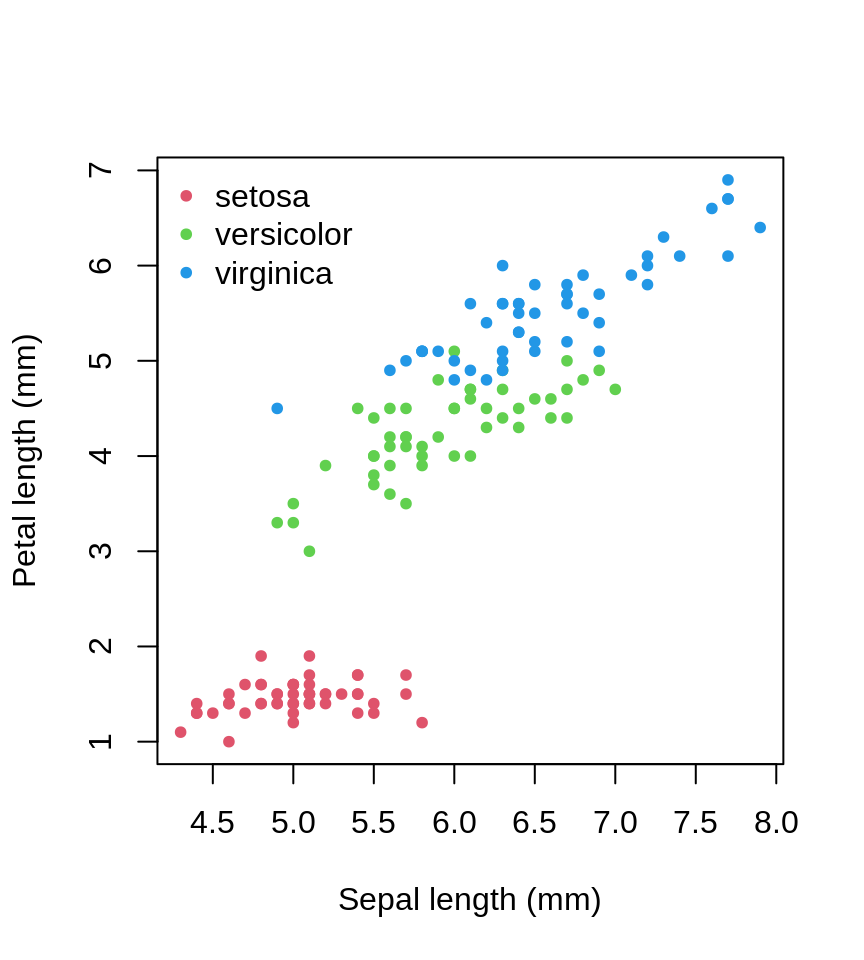

```r
# base graphics
plot(iris$Sepal.Length, iris$Petal.Length, pch = 20,
     col = as.numeric(iris$Species) + 1,
     xlab = "Sepal length (mm)", ylab = "Petal length (mm)")
legend("topleft", levels(iris$Species), pch = 20, col = 2:4, bty = "n")
```

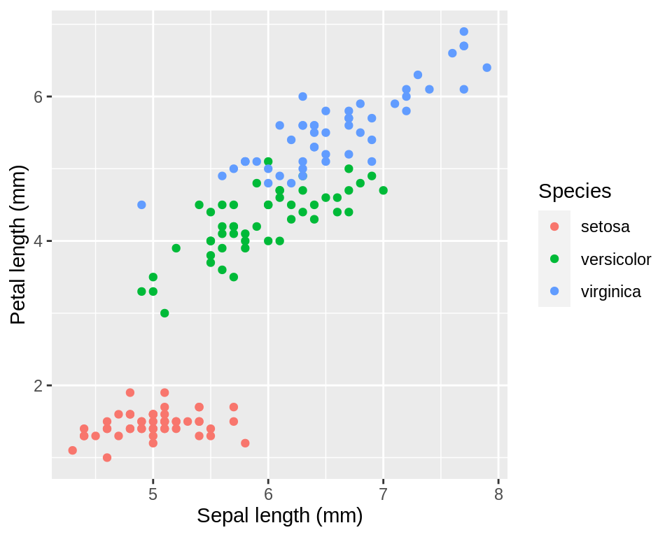

```r
# ggplot2
library(ggplot2)
ggplot(iris, aes(x=Sepal.Length, y=Petal.Length, colour=Species)) +
         geom_point() +
         xlab("Sepal length (mm)") + ylab("Petal length (mm)")
```

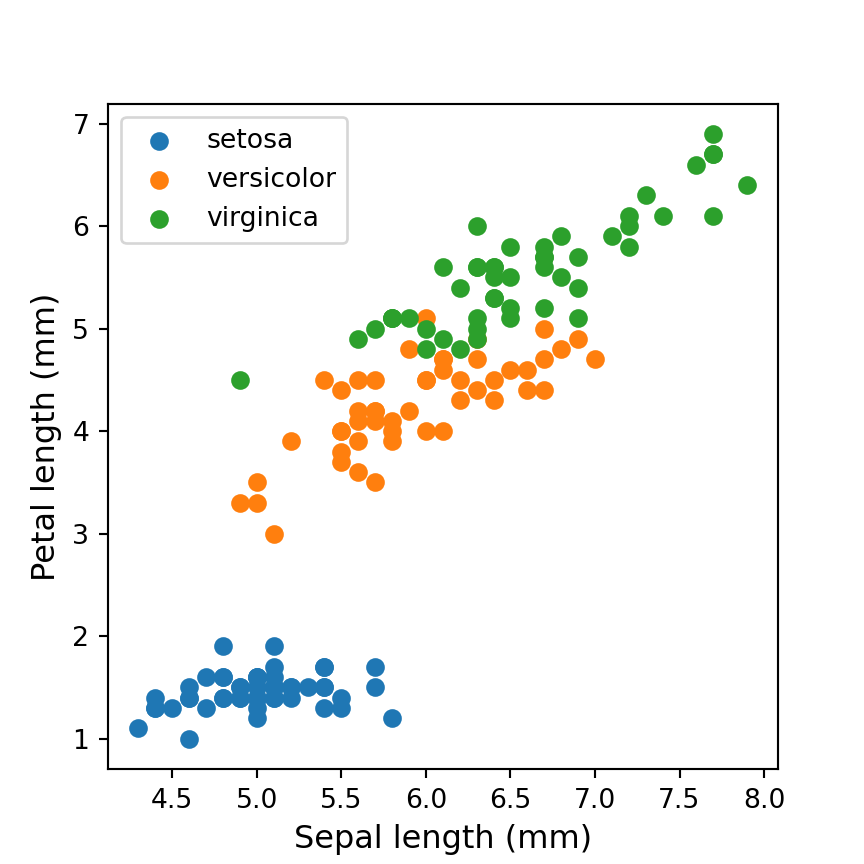

```python
import matplotlib
matplotlib.use('Agg', force = True)

import matplotlib.pyplot as plt

groups = pyiris.groupby('Species')

fig, ax = plt.subplots()

for name, group in groups:
    ax.scatter(x = group["Sepal.Length"], y = group["Petal.Length"], label=name)
ax.legend()

ax.set_xlabel('Sepal length (mm)', fontsize=12)
ax.set_ylabel('Petal length (mm)', fontsize=12)
```

## 4.5 Arrays

Here is a quick summary of how R and Python differ in the way they represent arrays. For a more detailed discussion see this [link](https://rstudio.github.io/reticulate/articles/arrays.html).

Dense data (for example a matrix or 2-dimensional array) are stored contiguously in memory, addressed by a single index (the memory address). Array memory ordering schemes translate that single index into multiple indices corresponding to the array coordinates. For example, matrices have two indices: rows and columns.

R and Python differ in their memory ordering schemes: R is so called “column-major”, meaning that data is layed-out in memory such that the first coordinate is the one changing fastest. To matrix element `x[i, j]` (1-based indices) for example can be found at index `a = i + (j - 1) * nrow(x)`.

Python/NumPy can store arrays both in “column-major” and also “row-major” form, but it defaults to the “row-major” format. In a row-major layout, the above example element `x[i, j]` would be found at index `a = j + (i - 1) * ncol(x)`.

If you are using/addressing arrays both in Python and R, it is good to know:

- Dense R arrays are presented to Python/NumPy as column-major NumPy arrays.
- All NumPy arrays (column-major, row-major, otherwise) are presented to R as column-major arrays, because that is the only kind of dense array that R understands.
- R and Python print arrays differently.

The different order of printing may be especially confusing, as illustrated in the code below. In this example, we use reticulate’s `import` function to access a Python module and create a NumPy array, and `py_to_r()` to explicitely convert it to an R array:

```r
# create a numpy array
np <- import("numpy", convert=FALSE)
aP <- np$arange(1, 9)$reshape(2L, 2L, 2L)
class(aP)
```

```
## [1] "numpy.ndarray"         "python.builtin.object"
```

```r
# print it
aP
```

```
## [[[1. 2.]
##   [3. 4.]]
##
##  [[5. 6.]
##   [7. 8.]]]
```

```r
# convert it to R
aR <- py_to_r(aP)
class(aR)
```

```
## [1] "array"
```

```r
# print it
aR
```

```
## , , 1
##
##      [,1] [,2]
## [1,]    1    3
## [2,]    5    7
##
## , , 2
##
##      [,1] [,2]
## [1,]    2    4
## [2,]    6    8
```

In Python, the array `.flags` tell us if the storage layout is row-major (`C_CONTIGUOUS`, from C-style) or column-major (`F_CONTIGUOUS`, from Fortran-style):

```python
np.arange(1, 9).reshape(2, 2, 2).flags
```

```
##   C_CONTIGUOUS : True
##   F_CONTIGUOUS : False
##   OWNDATA : False
##   WRITEABLE : True
##   ALIGNED : True
##   WRITEBACKIFCOPY : False
##   UPDATEIFCOPY : False
```

While the two arrays `aP` and `aR` may look different at first, the indeed are the same. For illustration, let’s pick out values along just the first “row”, that is values with a first index of 1 (R) or 0 (Python):

```r
# compare the sub-arrays at the first index of the first dimension
aR[1, , ]
```

```
##      [,1] [,2]
## [1,]    1    2
## [2,]    3    4
```

```r
aP[0]
```

```
## [[1. 2.]
##  [3. 4.]]
```

As mentioned, more details are discussed [here](https://rstudio.github.io/reticulate/articles/arrays.html).

## 4.6 Sparse matrices

If [scipy](https://scipy.org/) is installed, [reticulate](https://rstudio.github.io/reticulate/) will automatically convert R `dgcMatrix` sparse matrix objects to [SciPy CSC matrix](https://docs.scipy.org/doc/scipy/reference/generated/scipy.sparse.csc_matrix.html) objects. Without a working [scipy](https://scipy.org/) installation, the code below will throw a “cannot convert object” error.

```r
# load Matrix package and create sparse matrix A
library(Matrix)
i <- c(1,3:8)
j <- c(2,9,6:10)
x <- 7 * (1:7)
A <- sparseMatrix(i, j, x = x)
A
```

```
## 8 x 10 sparse Matrix of class "dgCMatrix"
##
## [1,] . 7 . . .  .  .  .  .  .
## [2,] . . . . .  .  .  .  .  .
## [3,] . . . . .  .  .  . 14  .
## [4,] . . . . . 21  .  .  .  .
## [5,] . . . . .  . 28  .  .  .
## [6,] . . . . .  .  . 35  .  .
## [7,] . . . . .  .  .  . 42  .
## [8,] . . . . .  .  .  .  . 49
```

```python
# automatic conversion to SciPy CSC matrix (requires scipy)
r.A
```

```
## <8x10 sparse matrix of type '<class 'numpy.float64'>'
##  with 7 stored elements in Compressed Sparse Column format>
```

```python
r.A.shape
```

```
## (8, 10)
```

# 5 Final remarks

- When sharing objects between Python and R, the object is often copied. In specific cases (e.g., numpy arrays), the object may not be copied (R and Python point to the same object in memory).
- R and Python use different default numeric types - if Python expects an integer, be sure to add L in R (e.g. `3L`).
- Keep in mind that Python uses 0-based indices, while R uses 1-based.
- Dots (‘.’) are not allowed in object names in Python. To avoid any issues, it is best to use names for your R objects without any dots.

# 6 Session info

It’s good practise to include information on all used software and their version at the end of the document. For R, we can use the built-in `sessionInfo()` function, for python we can for example use the `sinfo` package:

## 6.1 R

```r
date()
```

```
## [1] "Tue May 26 19:26:02 2020"
```

[session information not shown]

## 6.2 Python

```python
from sinfo import sinfo
sinfo()
```

```
## -----
## matplotlib  3.2.1
## numpy       1.18.4
## pandas      1.0.3
## sinfo       0.3.1
## -----
## Python 3.6.8 (default, Aug  7 2019, 17:28:10) [GCC 4.8.5 20150623 (Red Hat 4.8.5-39)]
## Linux-3.10.0-1062.18.1.el7.x86_64-x86_64-with-centos-7.7.1908-Core
## 96 logical CPU cores, x86_64
## -----
## Session information updated at 2020-05-26 19:26
```